# spsur: an R package for estimation and inference of spatial SUR models

XI Jornadas de usuarios de R. Madrid

Román Mínguez, Universidad Castilla-La Mancha (Spain); Fernando López, Universidad Politécnica de Cartagena (Spain); Jesús Mur Universidad de Zaragoza (Spain)

14-16 Noviembre (2019)

Abstract

A collection of functions to test and estimate Spatial Seemingly Unrelated Regression (SUR) models by maximum likelihood and three-stage least square for the more usual SUR specifications with spatial effects (SUR-SLX; SUR-SLM; SUR-SEM;SUR-SDM; SUR-SDEM and SUR-SARAR) and non spatial SUR model (SUR-SIM).

# Motivation

1. From Zellner (1962) Seemingly Unrelated Model (SUR) is a popular model in Econometrics.
2. Spatial SUR models are a powerful multi-equational models in Spatial Econometrics.
> - Could be used to take account spatial autocorrelation and temporal correlation.
> - Correlation between residual of different equations for same cross section.
> - Even could be used in a panel data framework (López et al. 2010).

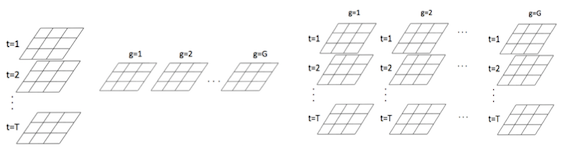

## We think that `spsur` will be a welcome R-package to estimate Spatial SUR model

# Before to present the `spsur` package:

## 0.1 Data sets in `spsur`

The `spsur` package include several data sets:

### The spc (Spatial Phillips-Curve). A classical data set from Anselin (1988, p.203)

A total of N=25 observations and Tm=2 time periods

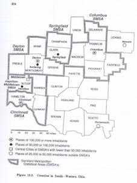

| COUNTY | WAGE83 | UN83 | NMR83 | SMSA | WAGE82 | WAGE81 | UN80 | NMR80 | WAGE80 |
| --- | --- | --- | --- | --- | --- | --- | --- | --- | --- |
| UNION | 1.003127 | 0.080500 | -0.002217 | 1 | 1.108662 | 1.146178 | 0.130375 | -0.010875 | 1.084886 |
| DELAWARE | 1.039972 | 0.122174 | 0.018268 | 1 | 1.071271 | 1.104241 | 0.189603 | 0.041886 | 1.110426 |
| LICKING | 1.050196 | 0.095821 | -0.013681 | 1 | 1.058375 | 1.094732 | 0.124125 | -0.004158 | 1.069776 |

### 2. Homicides + Socio-Economics characteristics for U.S. counties (1960-90)

from [https://geodacenter.github.io/data-and-lab/ncovr/]

Homicides and selected socio-economic characteristics for continental U.S. counties. Data for four decennial census years: 1960, 1970, 1980 and 1990.  
A total of N=3085 US counties

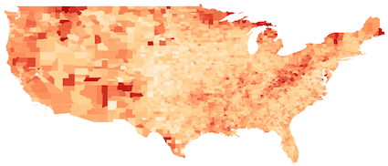

| NAME | STATE_NAME | STATE_FIPS | CNTY_FIPS | FIPS | STFIPS | COFIPS | FIPSNO | SOUTH |
| --- | --- | --- | --- | --- | --- | --- | --- | --- |
| Lake of the Woods | Minnesota | 27 | 077 | 27077 | 27 | 77 | 27077 | 0 |
| Ferry | Washington | 53 | 019 | 53019 | 53 | 19 | 53019 | 0 |
| Stevens | Washington | 53 | 065 | 53065 | 53 | 65 | 53065 | 0 |

## 0.2 How to specify multiple equations: The `Formula` package

By example: two equations with different number of regressors

> $Y_{1} = \beta_{10} + \beta_{11} \ X_{11}+\beta_{12}X_{12}+\epsilon_{1}$  
> $Y_{2} = \beta_{20} + \beta_{21} \ X_{21}+\epsilon_{2}$

> formula <- $Y_{1}$ | $Y_{2}$ ~ $X_{11}$ + $X_{12}$ | $X_{21}$

# The `spsur` package step by step

### Step 1: Testing for spatial effects

### Step 2: Estimation of the Spatial SUR models

### Step 3: Looking for the correct especification

### Step 4: Impacts: Directs, Indirects and Total effects

### Step 5: `spsur` in a panel data framework

### Step 6: Additional functionalities

### Step 7: Conclusion and work to do

# Step 1: Testing for: `lmtestspsur`

The function `lmtestspsur` obtain five LM statistis for testing spatial dependence in Seemingly Unrelated Regression models  
(Mur J, López FA, Herrera M, 2010: Testing for spatial effect in Seemingly Unrelated Regressions. *Spatial Economic Analysis* 5(4) 399-440).

> $H_{0}:$ No spatial autocorrelation  
> $H_{A}:$ SUR-SLM or  
> $H_{A}:$ SUR-SEM or  
> $H_{A}:$ SUR-SARAR
- **LM-SUR-SLM**
- **LM-SUR-SEM**
- **LM-SUR-SARAR**

and two robust LM tests

- **LM*-SUR-SLM**
- **LM*-SUR-SEM**

#### Example 1: with Anselin’s data we can test spatial effects in the SUR model:

> $WAGE_{83} = \beta_{10} + \beta_{11} \ UN_{83} + \beta_{12} \ NMR_{83} + \beta_{13} \ SMSA + \epsilon_{83}$  
> $WAGE_{81} = \beta_{20} + \beta_{21} \ UN_{80} + \beta_{22} \ NMR_{80} + \beta_{23} \ SMSA+ \epsilon_{81}$  
> $Corr(\epsilon_{83},\epsilon_{81}) \neq 0$

```r
library(spsur)
data("spc")
Tformula <- WAGE83 | WAGE81 ~ UN83 + NMR83 + SMSA | UN80 + NMR80 + SMSA
LMs <- lmtestspsur(Form = Tformula, data = spc, W = Wspc)
```

```
##              LM-Stat. DF p-value
## LM-SUR-SLM     5.2472  2  0.0725 .
## LM-SUR-SEM     3.3050  2  0.1916
## LM*-SUR-SLM    2.1050  2  0.3491
## LM*-SUR-SEM    0.1628  2  0.9218
## LM-SUR-SARAR   5.7703  4  0.2170
## ---
## Signif. codes:  0 '***' 0.001 '**' 0.01 '*' 0.05 '.' 0.1 ' ' 1
```

In this example no spatial autocorrelation is identified! (25 observations).

#### Example 2: Homicides + Socio-Economics data (year 1980)

> With **different number** of exogenous variables in each equation

> $HR_{80} = \beta_{10} + \beta_{11} \ PS_{80} + \beta_{12} \ UE_{80} + \epsilon_{HR}$  
> $DV_{80} = \beta_{20} + \beta_{21} \ PS_{80} + \beta_{22} \ UE_{80} + \beta_{23} \ SOUTH + \epsilon_{DV}$  
> $FP_{79} = \beta_{30} + \beta_{31} \ PS_{80}+ \epsilon_{FP}$

```r
Tformula <- HR80 | DV80  | FP79 ~ PS80 + UE80 | PS80 + UE80 + SOUTH | PS80
LMs <- lmtestspsur(Form = Tformula, data = NCOVR, W = W)
```

```
##              LM-Stat. DF  p-value
## LM-SUR-SLM    5494.02  3  < 2e-16 ***
## LM-SUR-SEM    5620.26  3  < 2e-16 ***
## LM*-SUR-SLM     53.16  3 1.69e-11 ***
## LM*-SUR-SEM    179.41  3  < 2e-16 ***
## LM-SUR-SARAR  5741.17  6  < 2e-16 ***
## ---
## Signif. codes:  0 '***' 0.001 '**' 0.01 '*' 0.05 '.' 0.1 ' ' 1
```

# Step 2: Estimation of a Spatial SUR

Two alternative estimation methods are implemented:

## 2.1. Maximum likelihood estimation: `spsurml`

Maximum likelihood estimation for differents spatial SUR models using `spsurml`. The models are:

> - **SUR-SIM:** with out spatial autocorrelation
> - **SUR-SLX:** Spatial Lag of X SUR model
> - **SUR-SLM:** Spatial Lag SUR model
> - **SUR-SEM:** Spatial Error SUR model
> - **SUR-SDM:** Spatial Durbin SUR model
> - **SUR-SDEM:** Spatial Durbin Error SUR model
> - **SUR-SARAR:** Spatial Lag with Spatial Error SUR model / (SUR-SAC)

### 2.1.1 Anselin data set

**SUR-SIM:** SUR model without spatial effects  
($y_{t} = X_{t} \beta_{t} + \epsilon_{t}; t=1,...,T$)

> $WAGE_{83} = \beta_{10} + \beta_{11} UN_{83} + \beta_{12} NMR_{83} + \beta_{13} SMSA + \epsilon_{83}$  
> $WAGE_{81} = \beta_{20} + \beta_{21} UN_{80} + \beta_{22} NMR_{80} + \beta_{23} SMSA+ \epsilon_{81}$  
> $Corr(\epsilon_{83},\epsilon_{81}) \neq 0$

```r
library(spsur)
Tformula <- WAGE83 | WAGE81 ~ UN83 + NMR83 + SMSA | UN80 + NMR80 + SMSA
spcsur.sim <- spsurml(Form = Tformula, data = spc, type = "sim", W = Wspc)
```

```
## Initial point:
## log_lik:  110.423
## Iteration:  1  log_lik:  111.201
## Iteration:  2  log_lik:  111.348
## Iteration:  3  log_lik:  111.378
## Time to fit the model:  0.16  seconds
## Time to compute covariances:  0.03  seconds
```

```r
summary(spcsur.sim)
```

```
## Call:
## spsurml(Form = Tformula, data = spc, W = Wspc, type = "sim")
##
##
## Spatial SUR model type:  sim
##
## Equation  1
##                 Estimate Std. Error t value Pr(>|t|)
## (Intercept)_1  0.9845592  0.0204381 48.1728  < 2e-16 ***
## UN83_1         0.6595414  0.2878689  2.2911  0.02744 *
## NMR83_1       -0.3772648  0.2699660 -1.3975  0.17018
## SMSA_1        -0.0085762  0.0131588 -0.6517  0.51839
## ---
## Signif. codes:  0 '***' 0.001 '**' 0.01 '*' 0.05 '.' 0.1 ' ' 1
## R-squared: 0.4224
##   Equation  2
##                Estimate Std. Error t value Pr(>|t|)
## (Intercept)_2  1.159370   0.045728 25.3535   <2e-16 ***
## UN80_2        -0.559787   0.414434 -1.3507   0.1846
## NMR80_2        0.583248   0.381367  1.5294   0.1342
## SMSA_2         0.010439   0.026166  0.3990   0.6921
## ---
## Signif. codes:  0 '***' 0.001 '**' 0.01 '*' 0.05 '.' 0.1 ' ' 1
## R-squared: 0.2757
##   Variance-Covariance Matrix of inter-equation residuals:
##   0.0004539866 -0.0006769556
##  -0.0006769556  0.0021133889
## Correlation Matrix of inter-equation residuals:
##   1.0000000 -0.6911129
##  -0.6911129  1.0000000
##
##  R-sq. pooled: 0.5328
##  Log-Likelihood:  111.378
##  Breusch-Pagan: 12.07  p-value: (0.000513)
```

Only change the **‘type’** argument in `spsurml` function it is possible to estimate several spatial model

**SUR-SLM:** Spatial autorregresive model:  
($y_{t} = \lambda_{t} Wy_{t} + X_{t} \beta_{t} + \epsilon_{t}; \ t=1,...,T$ )

> $WAGE_{83} = \lambda_{83} WWAGE_{83} + \beta_{10} + \beta_{11} UN_{83} + \beta_{12} NMR_{83} + \beta_{13} SMSA + \epsilon_{83}$  
> $WAGE_{81} = \lambda_{81} WWAGE_{81} + \beta_{20} + \beta_{21} UN_{80} + \beta_{22} NMR_{80} + \beta_{23} SMSA+ \epsilon_{81}$  
> $Corr(\epsilon_{83},\epsilon_{81}) \neq 0$

```r
spcsur.slm <- spsurml(Form = Tformula, data = spc, type = "slm", W = Wspc)
```

```
## Initial point:   log_lik:  113.197  lambdas:  -0.472 -0.446
## Iteration:  1   log_lik:  114.085  lambdas:  -0.506 -0.482
## Iteration:  2   log_lik:  114.096  lambdas:  -0.506 -0.482
## Time to fit the model:  2.64  seconds
## Computing marginal test...
## Time to compute covariances:  0.45  seconds
```

```r
summary(spcsur.slm)
```

```
## Call:
## spsurml(Form = Tformula, data = spc, W = Wspc, type = "slm")
##
##
## Spatial SUR model type:  slm
##
## Equation  1
##                 Estimate Std. Error t value  Pr(>|t|)
## (Intercept)_1  1.4955217  0.2467240  6.0615 5.183e-07 ***
## UN83_1         0.8070029  0.2557439  3.1555  0.003179 **
## NMR83_1       -0.5194114  0.2590550 -2.0050  0.052318 .
## SMSA_1        -0.0073247  0.0118519 -0.6180  0.540347
## lambda_1      -0.5057334  0.2405734 -2.1022  0.042401 *
## ---
## Signif. codes:  0 '***' 0.001 '**' 0.01 '*' 0.05 '.' 0.1 ' ' 1
## R-squared: 0.6224
##   Equation  2
##                 Estimate Std. Error t value  Pr(>|t|)
## (Intercept)_2  1.7094414  0.2925620  5.8430 1.024e-06 ***
## UN80_2        -0.6745562  0.3870737 -1.7427   0.08969 .
## NMR80_2        0.7502934  0.3842670  1.9525   0.05847 .
## SMSA_2         0.0014181  0.0241859  0.0586   0.95356
## lambda_2      -0.4821428  0.2557758 -1.8850   0.06730 .
## ---
## Signif. codes:  0 '***' 0.001 '**' 0.01 '*' 0.05 '.' 0.1 ' ' 1
## R-squared: 0.4743
##   Variance-Covariance Matrix of inter-equation residuals:
##   0.0003085954 -0.0003561928
##  -0.0003561928  0.0015864976
## Correlation Matrix of inter-equation residuals:
##   1.000000 -0.509062
##  -0.509062  1.000000
##
##  R-sq. pooled: 0.6603
##  Log-Likelihood:  114.096
##  Breusch-Pagan: 6.516  p-value: (0.0107)
##  LMM: 0.50489  p-value: (0.477)
```

**SUR-SEM:** Spatial error model:  
($y_{t} = X_{t}\ \beta_{t} + u_{t}\ ; u_{t}=\rho u_{t}+ \epsilon_{t}\ t=1,...,T$)

> $WAGE_{83} = \beta_{10} + \beta_{11} UN_{83} + \beta_{12} NMR_{83} + \beta_{13} SMSA + u_{83}; \ u_{83}=\rho W \ u_{83} + \epsilon_{83}$  
> $WAGE_{81} =\beta_{20} + \beta_{21} UN_{80} + \beta_{22} NMR_{80} + \beta_{23} SMSA+ u_{81}; \ u_{81}=\rho W \ u_{81} + \epsilon_{81}$  
> $Corr(\epsilon_{83},\epsilon_{81}) \neq 0$

```r
spcsur.sem <- spsurml(Form = Tformula, data = spc, type = "sem",
                     W = Wspc)
```

```
## Initial point:   log_lik:  112.821  deltas:  -0.556 -0.477
## Iteration:  1  log_lik:  113.695  rhos:  -0.618 -0.537
## Iteration:  2  log_lik:  113.719  rhos:  -0.628 -0.548
## Time to fit the model:  4.01  seconds
## Computing marginal test...
## Time to compute covariances:  0.41  seconds
```

```r
summary(spcsur.sem)
```

```
## Call:
## spsurml(Form = Tformula, data = spc, W = Wspc, type = "sem")
##
##
## Spatial SUR model type:  sem
##
## Equation  1
##                 Estimate Std. Error t value  Pr(>|t|)
## (Intercept)_1  0.9805218  0.0151899 64.5511 < 2.2e-16 ***
## UN83_1         0.7383349  0.2277247  3.2422  0.002513 **
## NMR83_1       -0.4859228  0.2550377 -1.9053  0.064535 .
## SMSA_1        -0.0132403  0.0099122 -1.3358  0.189790
## rho_1         -0.6280610  0.2774391 -2.2638  0.029541 *
## ---
## Signif. codes:  0 '***' 0.001 '**' 0.01 '*' 0.05 '.' 0.1 ' ' 1
## R-squared: 0.6607
##   Equation  2
##                 Estimate Std. Error t value Pr(>|t|)
## (Intercept)_2  1.1479484  0.0386961 29.6657  < 2e-16 ***
## UN80_2        -0.4406330  0.3614882 -1.2189  0.23058
## NMR80_2        0.8223976  0.4062173  2.0245  0.05018 .
## SMSA_2         0.0041942  0.0204639  0.2050  0.83873
## rho_2         -0.5480668  0.2817155 -1.9455  0.05935 .
## ---
## Signif. codes:  0 '***' 0.001 '**' 0.01 '*' 0.05 '.' 0.1 ' ' 1
## R-squared: 0.5092
##   Variance-Covariance Matrix of inter-equation residuals:
##   0.0002970481 -0.0003217158
##  -0.0003217158  0.0015512097
## Correlation Matrix of inter-equation residuals:
##   1.0000000 -0.4739403
##  -0.4739403  1.0000000
##
##  R-sq. pooled: 0.673
##  Log-Likelihood:  113.719
##  Breusch-Pagan: 5.512  p-value: (0.0189)
##  LMM: 1.4742  p-value: (0.225)
```

**SUR-SARAR:** Spatial autoregressive model with spatial autoregressive error term:  
($y_{t} = \lambda_{t} Wy_{t} + X_{t}\ \beta_{t} + u_{t}\ ; u_{t}=\rho_{t} u_{t}+ \epsilon_{t}\ t=1,...,T$)

```r
spcsur.sarar <- spsurml(Form = Tformula, data = spc,
                        type = "sarar", W = Wspc)
```

```
## Initial point:   log_lik:  113.406  lambdas:  -0.343 -0.526  rhos:  -0.28 0.113
## Iteration:  1  log_lik:  114.574  lambdas:  -0.384 -0.783  rhos:  -0.307 0.411
## Iteration:  2  log_lik:  114.824  lambdas:  -0.394 -0.905  rhos:  -0.303 0.553
## Iteration:  3  log_lik:  115.019  lambdas:  -0.395 -0.995  rhos:  -0.296 0.657
## Iteration:  4  log_lik:  115.187  lambdas:  -0.388 -1  rhos:  -0.271 0.686
## Iteration:  5  log_lik:  115.237  lambdas:  -0.381 -1  rhos:  -0.254 0.699
## Iteration:  6  log_lik:  115.26  lambdas:  -0.376 -1  rhos:  -0.243 0.707
## Time to fit the model:  74.28  seconds
## Time to compute covariances:  0.53  seconds
```

```r
summary(spcsur.sarar)
```

```
## Call:
## spsurml(Form = Tformula, data = spc, W = Wspc, type = "sarar")
##
##
## Spatial SUR model type:  sarar
##
## Equation  1
##                Estimate Std. Error t value Pr(>|t|)
## (Intercept)_1  1.366431   0.530515  2.5757 0.014387 *
## UN83_1         0.776669   0.250334  3.1025 0.003782 **
## NMR83_1       -0.477594   0.243189 -1.9639 0.057526 .
## SMSA_1        -0.011898   0.011192 -1.0631 0.295019
## lambda_1      -0.375539   0.521539 -0.7201 0.476270
## rho_1         -0.242517   0.585142 -0.4145 0.681067
## ---
## Signif. codes:  0 '***' 0.001 '**' 0.01 '*' 0.05 '.' 0.1 ' ' 1
## R-squared: 0.6488
##   Equation  2
##                Estimate Std. Error t value  Pr(>|t|)
## (Intercept)_2  2.261235   0.309798  7.2990 1.578e-08 ***
## UN80_2        -0.600803   0.324573 -1.8511 0.0726153 .
## NMR80_2        0.422431   0.280569  1.5056 0.1411370
## SMSA_2         0.020267   0.026531  0.7639 0.4500581
## lambda_2      -1.000000   0.283853 -3.5229 0.0012094 **
## rho_2          0.707014   0.180791  3.9107 0.0004039 ***
## ---
## Signif. codes:  0 '***' 0.001 '**' 0.01 '*' 0.05 '.' 0.1 ' ' 1
## R-squared: 0.6785
##   Variance-Covariance Matrix of inter-equation residuals:
##   0.0003134325 -0.0003735885
##  -0.0003735885  0.0012071470
## Correlation Matrix of inter-equation residuals:
##   1.0000000 -0.6073533
##  -0.6073533  1.0000000
##
##  R-sq. pooled: 0.7421
##  Log-Likelihood:  115.26
##  Breusch-Pagan: 9.432  p-value: (0.00213)
```

### 2.1.2 Homicides + Socio-Economics (counties U.S.)

It is a **fast code**. Note the time to estimate a SUR-SLM with **3085 observations**

**SUR-SLM:** Spatial autorregresive model  
($y_{g} = \lambda_{g} Wy_{g} + X_{g} \beta_{g} + \epsilon_{g}; g=1,...,G$)

> $HR_{80} = \lambda_{HR} \ W HR_{80} + \beta_{10} + \beta_{11} PS_{80} + \beta_{12} UE_{80} + \epsilon_{HR}$  
> $DV_{80} = \lambda_{DV} \ W DV_{80} + \beta_{20} + \beta_{21} PS_{80} + \beta_{22} UE_{80} + \beta_{23} SOUTH + \epsilon_{DV}$  
> $FP_{79} = \lambda_{FP} \ W FP_{80} +\beta_{30} + \beta_{31} PS_{80}+ \epsilon_{FP}$

```r
data(NCOVR)
Tformula <- HR80 | DV80  | FP79 ~ PS80 + UE80 | PS80 + UE80 + SOUTH | PS80
NCOVR.slm <- spsurml(Form = Tformula, data = NCOVR,
                        type = "slm", W = W)
```

```
## Initial point:   log_lik:  -23517.27  lambdas:  0.483 0.6 0.631
## Iteration:  1   log_lik:  -22866.07  lambdas:  0.531 0.676 0.742
## Iteration:  2   log_lik:  -22857.5  lambdas:  0.535 0.681 0.754
## Iteration:  3   log_lik:  -22857.42  lambdas:  0.535 0.681 0.755
## Iteration:  4   log_lik:  -22857.42  lambdas:  0.535 0.682 0.755
## Time to fit the model:  60.5  seconds
## Computing marginal test...
## Time to compute covariances:  80.74  seconds
```

```r
summary(NCOVR.slm)
```

```
## Call:
## spsurml(Form = Tformula, data = NCOVR, W = W, type = "slm")
##
##
## Spatial SUR model type:  slm
##
## Equation  1
##               Estimate Std. Error t value  Pr(>|t|)
## (Intercept)_1 3.071086   0.259058 11.8548 < 2.2e-16 ***
## PS80_1        0.586514   0.105973  5.5346 3.205e-08 ***
## UE80_1        0.019488   0.029405  0.6627    0.5075
## lambda_1      0.535116   0.019782 27.0500 < 2.2e-16 ***
## ---
## Signif. codes:  0 '***' 0.001 '**' 0.01 '*' 0.05 '.' 0.1 ' ' 1
## R-squared: 0.3073
##   Equation  2
##                 Estimate Std. Error t value  Pr(>|t|)
## (Intercept)_2  1.1722435  0.0777687 15.0735 < 2.2e-16 ***
## PS80_2         0.2254169  0.0201623 11.1801 < 2.2e-16 ***
## UE80_2         0.0466581  0.0059494  7.8425 4.906e-15 ***
## SOUTH_2       -0.0410865  0.0364872 -1.1261    0.2602
## lambda_2       0.6815370  0.0157209 43.3522 < 2.2e-16 ***
## ---
## Signif. codes:  0 '***' 0.001 '**' 0.01 '*' 0.05 '.' 0.1 ' ' 1
## R-squared: 0.4963
##   Equation  3
##                Estimate Std. Error t value  Pr(>|t|)
## (Intercept)_3  3.075015   0.173143  17.760 < 2.2e-16 ***
## PS80_3        -1.079371   0.073941 -14.598 < 2.2e-16 ***
## lambda_3       0.754926   0.012749  59.213 < 2.2e-16 ***
## ---
## Signif. codes:  0 '***' 0.001 '**' 0.01 '*' 0.05 '.' 0.1 ' ' 1
## R-squared: 0.6614
##   Variance-Covariance Matrix of inter-equation residuals:
##  33.560725  1.2156559  8.1704643
##   1.215656  1.0940407 -0.4140781
##   8.170464 -0.4140781 13.9640107
## Correlation Matrix of inter-equation residuals:
##  1.0000000  0.2006219  0.3774209
##  0.2006219  1.0000000 -0.1059401
##  0.3774209 -0.1059401  1.0000000
##
##  R-sq. pooled: 0.6038
##  Log-Likelihood:  -22857.4
##  Breusch-Pagan: 598.2  p-value: (2.43e-129)
##  LMM: 176.42  p-value: (5.22e-38)
```

## 2.2. Three-Stage Least Square estimation (3SLS): `spsur3sls`

The function `spsur3sls` estimate by IV the models

- **SUR-SLM:** Spatial lag model
- **SUR-SDM:** Spatial Durbin model

By example:

> $HR_{80} = \lambda_{HR} \ W HR_{80} + \beta_{10} + \beta_{11} PS_{80} + \beta_{12} UE_{80} + \epsilon_{HR}$  
> $DV_{80} = \lambda_{DV} \ W DV_{80} + \beta_{20} + \beta_{21} PS_{80} + \beta_{22} UE_{80} + \beta_{23} SOUTH + \epsilon_{DV}$  
> $FP_{79} = \lambda_{FP} \ W FP_{80} +\beta_{30} + \beta_{31} PS_{80}+ \epsilon_{FP}$

```r
data(NCOVR)
Tformula <- HR80 | DV80  | FP79 ~ PS80 + UE80 | PS80 + UE80 + SOUTH | PS80
NCOVR.slm.3sls <- spsur3sls(Form = Tformula, data = NCOVR,
                             type = "slm", W = W, maxlagW = 2)
```

```
## Time to fit the model:  0.37  seconds
```

```r
summary(NCOVR.slm.3sls)
```

```
## Call:
## spsur3sls(Form = Tformula, data = NCOVR, W = W, type = "slm",
##     maxlagW = 2)
##
##
## Spatial SUR model type:  slm
##
## Equation  1
##                Estimate Std. Error t value  Pr(>|t|)
## (Intercept)_1  8.877617   1.307821  6.7881 1.206e-11 ***
## PS80_1         0.892351   0.138898  6.4245 1.388e-10 ***
## UE80_1        -0.060245   0.033200 -1.8146   0.06962 .
## lambda_1      -0.221472   0.191153 -1.1586   0.24664
## ---
## Signif. codes:  0 '***' 0.001 '**' 0.01 '*' 0.05 '.' 0.1 ' ' 1
## R-squared: 0.1405
##   Equation  2
##                Estimate Std. Error t value  Pr(>|t|)
## (Intercept)_2 2.9935206  0.3798303  7.8812  3.61e-15 ***
## PS80_2        0.2533626  0.0262643  9.6467 < 2.2e-16 ***
## UE80_2        0.0914432  0.0095959  9.5294 < 2.2e-16 ***
## SOUTH_2       0.0346575  0.0471028  0.7358    0.4619
## lambda_2      0.2124110  0.0900048  2.3600    0.0183 *
## ---
## Signif. codes:  0 '***' 0.001 '**' 0.01 '*' 0.05 '.' 0.1 ' ' 1
## R-squared: 0.291
##   Equation  3
##                Estimate Std. Error t value  Pr(>|t|)
## (Intercept)_3  7.670117   1.095699  7.0002 2.734e-12 ***
## PS80_3        -1.585681   0.160403 -9.8856 < 2.2e-16 ***
## lambda_3       0.386346   0.087474  4.4167 1.014e-05 ***
## ---
## Signif. codes:  0 '***' 0.001 '**' 0.01 '*' 0.05 '.' 0.1 ' ' 1
## R-squared: 0.5611
##   Variance-Covariance Matrix of inter-equation residuals:
##  45.377766  1.867308 18.961586
##   1.867308  1.938112 -1.427426
##  18.961586 -1.427426 34.820491
## Correlation Matrix of inter-equation residuals:
##  1.0000000  0.1991154  0.4770190
##  0.1991154  1.0000000 -0.1737588
##  0.4770190 -0.1737588  1.0000000
##
##  R-sq. pooled: 0.3595
```

# Step 3: Testing for misspecification in spatial SUR

## 3.1 Testing for the diagonality of $\Sigma$

The Breush-Pagan test of diagonality of $\Sigma$

> $H_{0}: \Sigma = \sigma^2 I_{R}$  
> $H_{A}: \Sigma \neq \sigma^2 I_{R}$

```r
summary(NCOVR.slm)
```

```
## Call:
## spsurml(Form = Tformula, data = NCOVR, W = W, type = "slm")
##
##
## Spatial SUR model type:  slm
##
## Equation  1
##               Estimate Std. Error t value  Pr(>|t|)
## (Intercept)_1 3.071086   0.259058 11.8548 < 2.2e-16 ***
## PS80_1        0.586514   0.105973  5.5346 3.205e-08 ***
## UE80_1        0.019488   0.029405  0.6627    0.5075
## lambda_1      0.535116   0.019782 27.0500 < 2.2e-16 ***
## ---
## Signif. codes:  0 '***' 0.001 '**' 0.01 '*' 0.05 '.' 0.1 ' ' 1
## R-squared: 0.3073
##   Equation  2
##                 Estimate Std. Error t value  Pr(>|t|)
## (Intercept)_2  1.1722435  0.0777687 15.0735 < 2.2e-16 ***
## PS80_2         0.2254169  0.0201623 11.1801 < 2.2e-16 ***
## UE80_2         0.0466581  0.0059494  7.8425 4.906e-15 ***
## SOUTH_2       -0.0410865  0.0364872 -1.1261    0.2602
## lambda_2       0.6815370  0.0157209 43.3522 < 2.2e-16 ***
## ---
## Signif. codes:  0 '***' 0.001 '**' 0.01 '*' 0.05 '.' 0.1 ' ' 1
## R-squared: 0.4963
##   Equation  3
##                Estimate Std. Error t value  Pr(>|t|)
## (Intercept)_3  3.075015   0.173143  17.760 < 2.2e-16 ***
## PS80_3        -1.079371   0.073941 -14.598 < 2.2e-16 ***
## lambda_3       0.754926   0.012749  59.213 < 2.2e-16 ***
## ---
## Signif. codes:  0 '***' 0.001 '**' 0.01 '*' 0.05 '.' 0.1 ' ' 1
## R-squared: 0.6614
##   Variance-Covariance Matrix of inter-equation residuals:
##  33.560725  1.2156559  8.1704643
##   1.215656  1.0940407 -0.4140781
##   8.170464 -0.4140781 13.9640107
## Correlation Matrix of inter-equation residuals:
##  1.0000000  0.2006219  0.3774209
##  0.2006219  1.0000000 -0.1059401
##  0.3774209 -0.1059401  1.0000000
##
##  R-sq. pooled: 0.6038
##  Log-Likelihood:  -22857.4
##  Breusch-Pagan: 598.2  p-value: (2.43e-129)
##  LMM: 176.42  p-value: (5.22e-38)
```

## 3.2 Marginal tests: $LM(\rho|\lambda)$ & $LM(\lambda|\rho)$

The Marginal Multiplier tests (LMM) are used to test for no correlation in one part of the model allowing for spatial correlation in the other. (Mur J, López FA and Herrera M, 2010)

> - The $LM(\rho|\lambda)$ is the test for spatial error correlation in a model with subtantive spatial correlation (SUR-SLM; SUR-SDM).

> $H_{0}: SUR-SLM$  
> $H_{A}: SUR-SARAR$

```r
summary(spcsur.slm)
```

```
## Call:
## spsurml(Form = Tformula, data = spc, W = Wspc, type = "slm")
##
##
## Spatial SUR model type:  slm
##
## Equation  1
##                 Estimate Std. Error t value  Pr(>|t|)
## (Intercept)_1  1.4955217  0.2467240  6.0615 5.183e-07 ***
## UN83_1         0.8070029  0.2557439  3.1555  0.003179 **
## NMR83_1       -0.5194114  0.2590550 -2.0050  0.052318 .
## SMSA_1        -0.0073247  0.0118519 -0.6180  0.540347
## lambda_1      -0.5057334  0.2405734 -2.1022  0.042401 *
## ---
## Signif. codes:  0 '***' 0.001 '**' 0.01 '*' 0.05 '.' 0.1 ' ' 1
## R-squared: 0.6224
##   Equation  2
##                 Estimate Std. Error t value  Pr(>|t|)
## (Intercept)_2  1.7094414  0.2925620  5.8430 1.024e-06 ***
## UN80_2        -0.6745562  0.3870737 -1.7427   0.08969 .
## NMR80_2        0.7502934  0.3842670  1.9525   0.05847 .
## SMSA_2         0.0014181  0.0241859  0.0586   0.95356
## lambda_2      -0.4821428  0.2557758 -1.8850   0.06730 .
## ---
## Signif. codes:  0 '***' 0.001 '**' 0.01 '*' 0.05 '.' 0.1 ' ' 1
## R-squared: 0.4743
##   Variance-Covariance Matrix of inter-equation residuals:
##   0.0003085954 -0.0003561928
##  -0.0003561928  0.0015864976
## Correlation Matrix of inter-equation residuals:
##   1.000000 -0.509062
##  -0.509062  1.000000
##
##  R-sq. pooled: 0.6603
##  Log-Likelihood:  114.096
##  Breusch-Pagan: 6.516  p-value: (0.0107)
##  LMM: 0.50489  p-value: (0.477)
```

> - The $LM(\lambda|\rho)$ is the test for subtantive spatial autocorrelation in a model with spatial autocorrelation in error term (SUR-SEM; SUR-SDEM).

> $H_{0}: SUR-SEM$  
> $H_{A}: SUR-SARAR$

```r
summary(spcsur.sem)
```

```
## Call:
## spsurml(Form = Tformula, data = spc, W = Wspc, type = "sem")
##
##
## Spatial SUR model type:  sem
##
## Equation  1
##                 Estimate Std. Error t value  Pr(>|t|)
## (Intercept)_1  0.9805218  0.0151899 64.5511 < 2.2e-16 ***
## UN83_1         0.7383349  0.2277247  3.2422  0.002513 **
## NMR83_1       -0.4859228  0.2550377 -1.9053  0.064535 .
## SMSA_1        -0.0132403  0.0099122 -1.3358  0.189790
## rho_1         -0.6280610  0.2774391 -2.2638  0.029541 *
## ---
## Signif. codes:  0 '***' 0.001 '**' 0.01 '*' 0.05 '.' 0.1 ' ' 1
## R-squared: 0.6607
##   Equation  2
##                 Estimate Std. Error t value Pr(>|t|)
## (Intercept)_2  1.1479484  0.0386961 29.6657  < 2e-16 ***
## UN80_2        -0.4406330  0.3614882 -1.2189  0.23058
## NMR80_2        0.8223976  0.4062173  2.0245  0.05018 .
## SMSA_2         0.0041942  0.0204639  0.2050  0.83873
## rho_2         -0.5480668  0.2817155 -1.9455  0.05935 .
## ---
## Signif. codes:  0 '***' 0.001 '**' 0.01 '*' 0.05 '.' 0.1 ' ' 1
## R-squared: 0.5092
##   Variance-Covariance Matrix of inter-equation residuals:
##   0.0002970481 -0.0003217158
##  -0.0003217158  0.0015512097
## Correlation Matrix of inter-equation residuals:
##   1.0000000 -0.4739403
##  -0.4739403  1.0000000
##
##  R-sq. pooled: 0.673
##  Log-Likelihood:  113.719
##  Breusch-Pagan: 5.512  p-value: (0.0189)
##  LMM: 1.4742  p-value: (0.225)
```

## 3.3 Coefficient stability/homogeneity

### 3.3.1 Wald tests for beta coefficients: `wald_betas`

In a **SUR-SLM** the model:

> $WAGE_{83} = \lambda_{83} W \ WAGE_{83} + \beta_{10} + \beta_{11} UN_{83} + \beta_{12} NMR_{83} + \boldsymbol{\beta_{13}} SMSA + \epsilon_{83}$  
> $WAGE_{81} = \lambda_{81} W \ WAGE_{81} + \beta_{20} + \beta_{21} UN_{80} + \beta_{22} NMR_{80} + \boldsymbol{\beta_{23}} SMSA + \epsilon_{81}$

It’s possible to test equality between SMSA coefficients in both equations:

> $H_{0}: \beta_{13} = \beta_{23}$  
> $H_{A}: \beta_{13} \neq \beta_{23}$

```r
Tformula <- WAGE83 | WAGE81 ~ UN83 + NMR83 + SMSA | UN80 + NMR80 + SMSA
spcsur.slm <- spsurml(Form = Tformula, data = spc,
                     type = "slm", W = Wspc,
                     control = list(tol = 0.05,
                                    maxit = 200, trace = FALSE))
R1 <- matrix(c(0,0,0,1,0,0,0,-1), nrow = 1)
r1 <- matrix(0, ncol = 1)
Wald_beta <- wald_betas(results = spcsur.slm, R = R1, b = r1)
```

```
## Wald stat.: 0.079 p-value: (0.779)
```

More complex hypothesis about $\beta$ coefficients could be tested using R1 vector

> $H_{0}: \beta_{13} = \beta_{23}$ and $\beta_{12} = \beta_{22}$  
> $H_{A}: \beta_{13} \neq \beta_{23}$ or $\beta_{12} \neq \beta_{22}$

```r
R1 <- t(matrix(c(0,0,0,1,0,0,0,-1,0,0,1,0,0,0,-1,0), ncol = 2))
r1 <- matrix(0, ncol = 2)
Wald_beta <- wald_betas(results = spcsur.slm, R = R1, b = r1)
```

```
## Wald stat.: 6.179 p-value: (0.046)
```

### Estimate the restricted model

> In case don’t reject the null, it’s possible to estimate the model with equal coefficient in both equations:

> $WAGE_{83} = \lambda_{83} W \ WAGE_{83} + \beta_{10} + \beta_{11} UN_{83} + \beta_{12} NMR_{83} + \boldsymbol{\beta_{13}} SMSA + \epsilon_{83}$  
> $WAGE_{81} = \lambda_{81} W \ WAGE_{81} + \beta_{20} + \beta_{21} UN_{80} + \beta_{22} NMR_{80} + \boldsymbol{\beta_{13}} SMSA + \epsilon_{81}$

```r
Tformula <- WAGE83 | WAGE81 ~ UN83 + NMR83 + SMSA | UN80 + NMR80 + SMSA
R1 <- matrix(c(0,0,0,1,0,0,0,-1), nrow = 1)
r1 <- matrix(0, ncol = 1)
spcsur.slm.restricted <- spsurml(Form = Tformula, data = spc, type = "slm", W = Wspc, R = R1, b = r1, control = list(tol = 0.05, maxit = 200, trace = FALSE))
summary(spcsur.slm.restricted)
```

```
## Call:
## spsurml(Form = Tformula, data = spc, R = R1, b = r1, W = Wspc,
##     type = "slm", control = list(tol = 0.05, maxit = 200, trace = FALSE))
##
##
## Spatial SUR model type:  slm
##
## Equation  1
##                 Estimate Std. Error t value  Pr(>|t|)
## (Intercept)_1  1.4876833  0.2444552  6.0857 4.343e-07 ***
## UN83_1         0.7486660  0.2290706  3.2683  0.002301 **
## NMR83_1       -0.4565917  0.2559136 -1.7842  0.082384 .
## SMSA_1        -0.0041128  0.0081857 -0.5024  0.618257
## lambda_1      -0.4950681  0.2392546 -2.0692  0.045377 *
## ---
## Signif. codes:  0 '***' 0.001 '**' 0.01 '*' 0.05 '.' 0.1 ' ' 1
## R-squared: 0.6115
##   Equation  2
##               Estimate Std. Error t value  Pr(>|t|)
## (Intercept)_2  1.69869    0.28885  5.8809 8.294e-07 ***
## UN80_2        -0.61498    0.32522 -1.8910   0.06627 .
## NMR80_2        0.68793    0.37391  1.8398   0.07362 .
## NA                  NA         NA      NA        NA
## lambda_2      -0.47556    0.25016 -1.9010   0.06490 .
## ---
## Signif. codes:  0 '***' 0.001 '**' 0.01 '*' 0.05 '.' 0.1 ' ' 1
## R-squared: 0.4691
##   Variance-Covariance Matrix of inter-equation residuals:
##   0.0003220152 -0.000394289
##  -0.0003942890  0.001616933
## Correlation Matrix of inter-equation residuals:
##   1.0000000 -0.5464249
##  -0.5464249  1.0000000
##
##  R-sq. pooled: 0.6531
##  Log-Likelihood:  114.049
##  Breusch-Pagan: 7.318  p-value: (0.00683)
##  LMM: 0.36616  p-value: (0.545)
```

### 3.3.2 Wald test for ‘spatial’ coefficients homogeneity: `wald_deltas`

In same way a test for equal spatial autocorrelation coefficients can be obtain with `wald_deltas` function:  
In the model:

> $WAGE_{83} = \boldsymbol{\lambda_{83}} W \ WAGE_{83} + \beta_{10} + \beta_{11} UN_{83} + \beta_{12} NMR_{83} + \beta_{13} SMSA + \epsilon_{83}$  
> $WAGE_{81} = \boldsymbol{\lambda_{81}} W \ WAGE_{81} + \beta_{20} + \beta_{21} UN_{80} + \beta_{22} NMR_{80} + \beta_{23} SMSA + \epsilon_{81}$

In this case the null is:

> $H_{0}: \lambda_{83} = \lambda_{81}$  
> $H_{A}: \lambda_{83} \neq \lambda_{81}$

```r
spcsur.slm <- spsurml(Form = Tformula, data = spc, type = "slm", W = Wspc, control = list(tol = 0.05, maxit = 200, trace = FALSE))
R1 <- matrix(c(1,-1), nrow = 1)
r1 <- matrix(0, ncol = 1)
res1 <- wald_deltas(results = spcsur.slm, R = R1, b = r1)
```

```
##
##  Wald stat.: 0.006 (0.939)
```

### 3.3.3 Likekihood ratio tests `lr_betas_spsur`

Alternatively to wald test, the Likelihoo Ration (LR) tests can be obtain using the `lr_betas_spsur` function.

```r
Tformula <- WAGE83 | WAGE81 ~ UN83 + NMR83 + SMSA | UN80 + NMR80 + SMSA
R <- matrix(c(0,0,0,1,0,0,0,-1),nrow=1)
r <- matrix(0,ncol=1)
LR_SMSA <-  lr_betas_spsur(Form = Tformula, data = spc, W = Wspc, type = "slm", R = R, b = r, trace = FALSE, printmodels = F)
```

```
##
##  Fitting unrestricted model ...
##
##  Time to fit unrestricted model:  2.81  seconds
##
##  Fitting restricted model ...
## Time to fit restricted model:  2.33  seconds
##
##  LR-Test
##
##  Log-likelihood unrestricted model:  114.096
##  Log-likelihood restricted model:  114.049
##  LR statistic:  0.095  degrees of freedom:  1  p-value: ( 0.7576548 )
```

# 4. Step 4: Marginal Effects: `impacts`

The marginal effects `impacts` of spatial autoregressive models (SUR-SLM; SUR-SDM; SUR-SARAR) has been calculated following the propose of LeSage and Pace (2009).

```r
Tformula <- WAGE83 | WAGE81 ~ UN83 + NMR83 + SMSA | UN80 + NMR80 + SMSA
spcsur.slm <-spsur3sls(Form = Tformula, data = spc, type = "slm", W = Wspc)
```

```
## Time to fit the model:  0.07  seconds
```

```r
eff.spcsur.slm <- impacts(spcsur.slm, nsim = 300)
```

```
##
## Spatial SUR model type:  slm
##
##  Direct effects
##
##             mean       sd  t-stat  p-val
## UN83_1  -1.21791 11.64101 -0.1046 0.9167
## NMR83_1  0.10074  4.01210  0.0251 0.9800
## SMSA_1  -1.70983 14.57275 -0.1173 0.9066
## UN80_2  -0.12248  2.07959 -0.0589 0.9530
## NMR80_2 -0.22363  3.32942 -0.0672 0.9464
## SMSA_2  -0.34441  2.84217 -0.1212 0.9035
##
##  Indirect effects
##
##             mean       sd  t-stat  p-val
## UN83_1  -10.9147 275.8821 -0.0396 0.9684
## NMR83_1   3.3726  94.8413  0.0356 0.9716
## SMSA_1  -20.0556 347.3637 -0.0577 0.9540
## UN80_2   -1.6451  37.0017 -0.0445 0.9645
## NMR80_2   4.9199  75.6581  0.0650 0.9482
## SMSA_2    4.5254  59.4598  0.0761 0.9393
##
##  Total effects
##
##             mean       sd  t-stat  p-val
## UN83_1  -12.1326 287.3677 -0.0422 0.9663
## NMR83_1   3.4733  98.8073  0.0352 0.9720
## SMSA_1  -21.7654 361.8445 -0.0602 0.9520
## UN80_2   -1.7676  38.4950 -0.0459 0.9634
## NMR80_2   4.6963  78.7740  0.0596 0.9525
## SMSA_2    4.1810  61.8978  0.0675 0.9461
```

# 5. Step 5: The `spsur` in a panel data framework

## 5.1 The `spsur` with G equation and T periods

Case of T temporal cross-sections and G equations

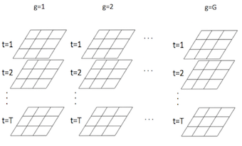

By example with NCOVR data set:

A **SUR-SLM-PANEL** model  
$y_{gt} = \lambda_{g} Wy_{gt} + X_{gt} \beta_{g} + \epsilon_{gt};$  
$\ g=1,...,G; \ t=1,...,T$  
$Corr(\epsilon_{gt},\epsilon_{g't})=Corr(\epsilon_{g},\epsilon_{g'}) \neq 0$ for $(\forall t)$

```r
## Case G = 1, T >1
## (temporal correlations)
data(NCOVR, package = "spsur")
N <- nrow(NCOVR)
Tm <- 4
index_time <- rep(1:Tm, each = N)
index_indiv <- rep(1:N, Tm)
pHR <- c(NCOVR$HR60, NCOVR$HR70, NCOVR$HR80, NCOVR$HR90)
pPS <- c(NCOVR$PS60, NCOVR$PS70, NCOVR$PS80, NCOVR$PS90)
pUE <- c(NCOVR$UE60, NCOVR$UE70, NCOVR$UE80, NCOVR$UE90)
pNCOVR <- data.frame(indiv = index_indiv, time = index_time,
                      HR = pHR, PS = pPS, UE = pUE)
rm(NCOVR,pHR,pPS,pUE,index_time,index_indiv)
form_pHR <- HR ~ PS + UE
pHR_slm <- spsurtime(Form = form_pHR, data = pNCOVR, W = W,
             time = pNCOVR$time, type = "slm",
             method = "3sls")
```

```
## Time to fit the model:  0.58  seconds
```

```r
summary(pHR_slm)
```

```
## Call:
## spsur3sls(W = W, X = X, Y = Y, G = G, N = N, Tm = Tm, p = p,
##     type = type, maxlagW = maxlagW)
##
##
## Spatial SUR model type:  slm
##
## Equation  1
##                Estimate Std. Error t value Pr(>|t|)
## (Intercept)_1  2.501017   1.645140  1.5202   0.1285
## PS_1          -0.029887   0.105860 -0.2823   0.7777
## UE_1           0.029898   0.046422  0.6441   0.5196
## lambda_1       0.405674   0.392876  1.0326   0.3018
## R-squared: 0.2843
##   Equation  2
##                Estimate Std. Error t value Pr(>|t|)
## (Intercept)_2 1.8871930  1.9497433  0.9679  0.33310
## PS_2          0.1705918  0.1651996  1.0326  0.30179
## UE_2          0.0099723  0.0497241  0.2006  0.84105
## lambda_2      0.6971788  0.2942217  2.3696  0.01782 *
## ---
## Signif. codes:  0 '***' 0.001 '**' 0.01 '*' 0.05 '.' 0.1 ' ' 1
## R-squared: 0.3604
##   Equation  3
##                Estimate Std. Error t value  Pr(>|t|)
## (Intercept)_3  6.881003   1.220794  5.6365 1.774e-08 ***
## PS_3           0.658929   0.135891  4.8489 1.256e-06 ***
## UE_3           0.183858   0.032266  5.6982 1.239e-08 ***
## lambda_3      -0.172457   0.178288 -0.9673    0.3334
## ---
## Signif. codes:  0 '***' 0.001 '**' 0.01 '*' 0.05 '.' 0.1 ' ' 1
## R-squared: 0.06152
##   Equation  4
##               Estimate Std. Error t value  Pr(>|t|)
## (Intercept)_4 3.917895   0.369609 10.6001 < 2.2e-16 ***
## PS_4          0.909703   0.119384  7.6200 2.723e-14 ***
## UE_4          0.319217   0.042374  7.5332 5.295e-14 ***
## lambda_4      0.023133   0.073747  0.3137    0.7538
## ---
## Signif. codes:  0 '***' 0.001 '**' 0.01 '*' 0.05 '.' 0.1 ' ' 1
## R-squared: 0.134
##   Variance-Covariance Matrix of inter-equation residuals:
##  31.72416 20.95984 16.31181 13.23690
##  20.95984 53.75722 26.29607 19.95032
##  16.31181 26.29607 45.37777 19.69094
##  13.23690 19.95032 19.69094 38.89755
## Correlation Matrix of inter-equation residuals:
##  1.0000000 0.5075448 0.4299180 0.3768166
##  0.5075448 1.0000000 0.5324158 0.4362851
##  0.4299180 0.5324158 1.0000000 0.4686880
##  0.3768166 0.4362851 0.4686880 1.0000000
##
##  R-sq. pooled: 0.1608
```

```r
## Case G > 1, T > 1
## (G equations correlated, non-temporal correlations)
data(NCOVR,package="spsur")
N <- nrow(NCOVR)
Tm <- 4
index_time <- rep(1:Tm, each = N)
index_indiv <- rep(1:N, Tm)
pHR <- c(NCOVR$HR60, NCOVR$HR70, NCOVR$HR80, NCOVR$HR90)
pPS <- c(NCOVR$PS60, NCOVR$PS70, NCOVR$PS80, NCOVR$PS90)
pUE <- c(NCOVR$UE60, NCOVR$UE70, NCOVR$UE80, NCOVR$UE90)
pDV <- c(NCOVR $DV60, NCOVR$DV70, NCOVR$DV80, NCOVR$DV90)
pFP <- c(NCOVR$FP59, NCOVR$FP70, NCOVR$FP80, NCOVR$FP90)
pSOUTH <- rep(NCOVR$SOUTH, Tm)
pNCOVR <- data.frame(indiv = index_indiv, time = index_time,
                      HR = pHR, PS = pPS, UE = pUE,
                      DV = pDV, FP = pFP, SOUTH = pSOUTH)
rm(NCOVR,pHR,pPS,pUE,pDV,pFP,pSOUTH,index_time,index_indiv)
pform <- HR | DV | FP ~ PS + UE | PS + UE + SOUTH | PS
psur_slm <- spsurml(Form = pform, data = pNCOVR, W = W,
                     type = "slm", cov = TRUE,
                  control = list(tol = 0.1, maxit = 200,                      trace = TRUE))
```

```
## Initial point:   log_lik:  -110108.7  lambdas:  0.512 0.722 0.677
## Iteration:  1   log_lik:  -101429.8  lambdas:  0.569 0.874 0.814
## Iteration:  2   log_lik:  -101177.6  lambdas:  0.575 0.889 0.828
## Iteration:  3   log_lik:  -101176.2  lambdas:  0.576 0.889 0.83
## Iteration:  4   log_lik:  -101176.2  lambdas:  0.576 0.889 0.83
## Time to fit the model:  53.14  seconds
## Computing marginal test...
## Time to compute covariances:  120.86  seconds
```

```r
summary(psur_slm)
```

```
## Call:
## spsurml(Form = pform, data = pNCOVR, W = W, type = "slm", cov = TRUE,
##     control = list(tol = 0.1, maxit = 200, trace = TRUE))
##
##
## Spatial SUR model type:  slm
##
## Equation  1
##                Estimate Std. Error t value  Pr(>|t|)
## (Intercept)_1 1.4276023  0.1160053 12.3064 < 2.2e-16 ***
## PS_1          0.3850142  0.0503341  7.6492 2.072e-14 ***
## UE_1          0.1903927  0.0167861 11.3423 < 2.2e-16 ***
## lambda_1      0.5761895  0.0097951 58.8242 < 2.2e-16 ***
## ---
## Signif. codes:  0 '***' 0.001 '**' 0.01 '*' 0.05 '.' 0.1 ' ' 1
## R-squared: 0.3369
##   Equation  2
##                 Estimate Std. Error  t value  Pr(>|t|)
## (Intercept)_2  0.1080582  0.0223635   4.8319 1.358e-06 ***
## PS_2           0.0991394  0.0090254  10.9845 < 2.2e-16 ***
## UE_2           0.0593327  0.0031309  18.9505 < 2.2e-16 ***
## SOUTH_2       -0.0033072  0.0171057  -0.1933    0.8467
## lambda_2       0.8894981  0.0040782 218.1109 < 2.2e-16 ***
## ---
## Signif. codes:  0 '***' 0.001 '**' 0.01 '*' 0.05 '.' 0.1 ' ' 1
## R-squared: 0.8496
##   Equation  3
##                 Estimate Std. Error t value  Pr(>|t|)
## (Intercept)_3  6.1240859  0.1793894  34.139 < 2.2e-16 ***
## PS_3          -3.5753721  0.0865753 -41.298 < 2.2e-16 ***
## lambda_3       0.8296673  0.0046025 180.264 < 2.2e-16 ***
## ---
## Signif. codes:  0 '***' 0.001 '**' 0.01 '*' 0.05 '.' 0.1 ' ' 1
## R-squared: 0.7695
##   Variance-Covariance Matrix of inter-equation residuals:
##  30.8081057  0.8012212  5.875745
##   0.8012212  0.9483969 -1.317446
##   5.8757453 -1.3174460 61.516789
## Correlation Matrix of inter-equation residuals:
##  1.0000000  0.1482262  0.1349689
##  0.1482262  1.0000000 -0.1724809
##  0.1349689 -0.1724809  1.0000000
##
##  R-sq. pooled: 0.9011
##  Log-Likelihood:  -101176
##  Breusch-Pagan:   863  p-value: (9.31e-187)
##  LMM: 1543.7  p-value: (   0)
```

# 6. Conclusion & work to do

> - `spsur` is a powerful R-package to test, estimate and looking for the correct specification
> - More functionalities estimation algorithm coming soon
>   - GMM estimation
>   - ML estimation with equal level of spatial dependence ($\lambda$/$\rho$=constant)
>   - Orthogonal demeaning for space-time SUR models
>   - …..
> - Integration with infrastructure of well-known spatial econometrics packages (`spatialreg`, `spdep`,…)
> - The `spsur` package is available in CRAN and GitHub [https://github.com/rominsal/spsur/]

# References

- López, F.A., P. J. Martínez-Ortiz, and J.G. Cegarra-Navarro (2017). Spatial spillovers in public expenditure on a municipal level in spain. *The Annals of Regional Science* 58 (1), 39–65.
- López, F.A., J. Mur, and A. Angulo (2014). Spatial model selection strategies in a sur framework. the case of regional productivity in eu. *The Annals of Regional Science* 53 (1), 197–220.
- Mur, J., F. López, and M. Herrera (2010). Testing for spatial effects in seemingly unrelated regressions. *Spatial Economic Analysis* 5 (4), 399–440.